# R Recap

Mark Dunning

Last modified: 23 Jul 2016

# Why use R?

## Advantages of R

The R programming language is now recognised beyond the academic community as an effect solution for data analysis and visualisation. [Notable users of R](http://www.revolutionanalytics.com/companies-using-r) include [Facebook](http://blog.revolutionanalytics.com/2010/12/analysis-of-facebook-status-updates.html), [google](http://blog.revolutionanalytics.com/2009/05/google-using-r-to-analyze-effectiveness-of-tv-ads.html), [Microsoft](http://blog.revolutionanalytics.com/2014/05/microsoft-uses-r-for-xbox-matchmaking.html) (who recently [invested](http://blogs.microsoft.com/blog/2015/01/23/microsoft-acquire-revolution-analytics-help-customers-find-big-data-value-advanced-statistical-analysis/) in a commerical provider of R), and the [New York Times](http://blog.revolutionanalytics.com/2011/03/how-the-new-york-times-uses-r-for-data-visualization.html).

## Key features

- Open-source
- Cross-platform
- Access to existing visualisation / statistical tools
- Flexibility
- Visualisation and interactivity
- Add-ons for many fields of research
- Facilitating *Reproducible Research*

## Support for R

- Online forums such as [Stack Overflow](http://stackoverflow.com/questions/tagged/r) regularly feature R
- [Blogs](http://www.r-bloggers.com/)
- Local [user groups](http://blog.revolutionanalytics.com/local-r-groups.html)
- Documentation via `?` or `help.start()`
- Packages analyse all kinds of Genomic data (>800)
- Compulsory documentation (*vignettes*) for each package
- 6-month release cycle
- [Course Materials](http://bioconductor.org/help/course-materials/)
- [Example data](http://bioconductor.org/packages/release/BiocViews.html#___ExperimentData) and [workflows](http://bioconductor.org/help/workflows/)
- Common, re-usable framework and functionality
- [Available Support](https://support.bioconductor.org/)
  - Often you will be able to interact with the package maintainers / developers and other power-users of the project software
- Annual conferences in U.S and Europe
  - The last European conference was in [Cambridge](https://sites.google.com/site/eurobioc2015/)

## The Bioconductor project

Many of the packages are by well-respected authors and get lots of citations.

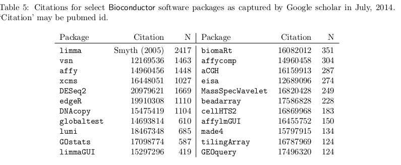

## Downloading a package

Each package has its own landing page. e.g. http://bioconductor.org/packages/release/bioc/html/beadarray.html. Here you’ll find;

- Installation script (will install all dependancies)
- Vignettes and manuals
- Details of package maintainer
- After downloading, you can load using the `library` function. e.g. `library(beadarray)`
- Only need to download once for each version of R
- CRAN packages installed by `install.packages`
- What packages to install?
  - [METACRAN](http://www.r-pkg.org/) can help

## RStudio

- Rstudio is a free environment for R
- Convenient menus to access scripts, display plots
- Still need to use *command-line* to get things done
- Developed by some of the leading R programmers

The **Packages** tab in the bottom-right panel of RStudio lists all packages that you currently have installed. Clicking on a package name will show a list of functions that available once that package has been loaded. The `library` function is used to load a package and make it’s functions / data available in your current R session. *You need to do this every time you load a new RStudio session*.

```r
library(beadarray)
```

There are functions for installing packages within R. If your package is part of the main **CRAN** repository, you can use `install.packages`

We will be using the `wakefield` R package in this practical. To install it, we would do.

```r
install.packages("wakefield")
```

*Bioconductor* packages have their own install script, which you can download from the Bioconductor website

```r
source("http://www.bioconductor.org/biocLite.R")
biocLite("affy")
```

A package may have several *dependancies*; other R packages from which it uses functions or data types (re-using code from other packages is strongly-encouraged). If this is the case, the other R packages will be located and installed too.

So long as you stick with the same version of R, you won’t need to repeat this install process.

Bioconductor packages also come with a *vignette*

- Often describing the workflow of using the package, and particular use-cases

R has an in-built help system. At the *console*, you can type `?` followed by the name of a function. This will bring-up the documentation for the function; which includes the expected inputs (*arguments*), the output you should expect from the function and some use-cases.

```r
?mean
```

## About the R markdown format

Aside from teaching you about NGS analysis, we also hope to teach you how to work in a reproducible manner. The first step in this process is to master the R markdown format.

Go File -> New File -> R Markdown in Rstudio now…..

Press Ok.

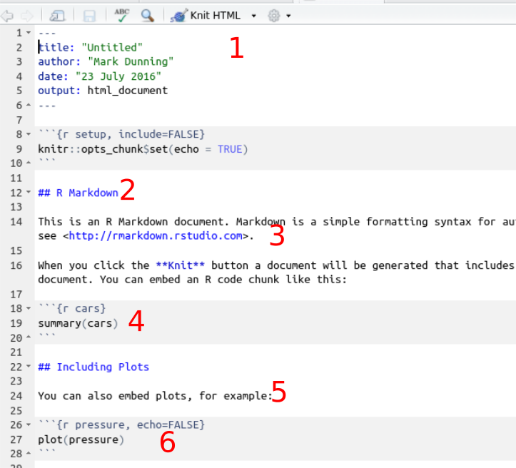

The “markdown” file is a template used to generate a report (in pdf, html or doc format). The report is a mix of R code and plain text. All R code gets run and the results appear in the final report.

1. Header information
2. Section heading
3. Plain text
4. R code to be run
5. Plain text
6. R code to be run
- Each line of R code can be executed in the R console by placing the cursor on the line and pressing `CTRL + ENTER`.
- You can also highlight multiple lines of code. NB. You do not need to highlight to the backtick (```) symbols.
- Hitting the knit HTML button will run all R code in order and (providing there are no errors!) you will get a PDF or HTML document.
  - the first time you try and knit you’ll need to specify a file name
- The resultant document will contain all the plain text you wrote, the R code, and any outputs (including graphs, tables etc) that R produced. You can then distribute this document to have a reproducible account of your analysis.

## How to use the template

- Most R sessions will have a markdown template that you can modify to complete the exercises
- We will also tell you what “working directory” you need to be in
  - the working directory is where RStudio will look to read data from, and save data to
- Change your name, add a title and date in the header section
- Add notes, explanations of code etc in the white space between code chunks. You can add new lines with `ENTER`. Clicking the `?` next to the `Knit HTML` button will give more information about how to format this text. You can introduce **bold** and *italics* for example.
- Some code chunks are left blank. These are for you to write the R code required to answer the questions
- You can try to knit the document at any point to see how it looks